# Prak 6 dan 7 MPDW

Annisa Marwah

2026-09-30

```r
library(readxl)
library(forecast)
library(tseries)
```

```r
library(ggplot2)
```

# Input Data

```r
data <- read_excel("Data Pilihan MPDW.xlsx")
data
```

```
## # A tibble: 100 × 2
##    Periode Jumlah_Penumpang
##      <dbl>            <dbl>
##  1       1            48208
##  2       2            55488
##  3       3            46777
##  4       4            57120
##  5       5            59794
##  6       6            59681
##  7       7            60904
##  8       8            64877
##  9       9            54788
## 10      10            52970
## # ℹ 90 more rows
```

# Pre-processing

```r
y <- data$Jumlah_Penumpang

sum(is.na(y))
```

```
## [1] 0
```

```r
y <- na.omit(y)
```

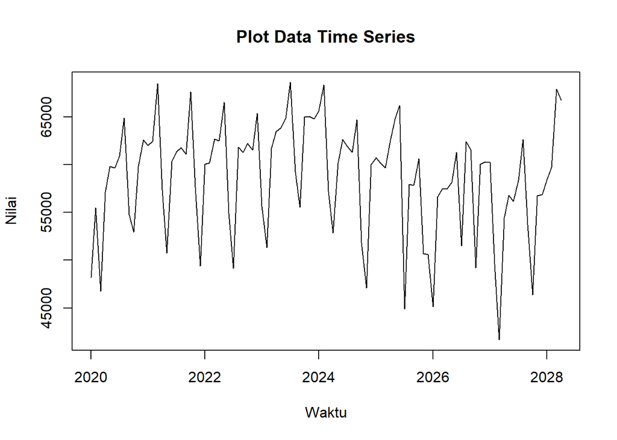

```r
y_ts <- ts(y,
           start = c(2020, 1),
           frequency = 12)

plot(y_ts,
     main = "Plot Data Time Series",
     xlab = "Waktu",
     ylab = "Nilai")
```

# Uji stasioneritas

```r
adf.test(y_ts)
```

```
##
##  Augmented Dickey-Fuller Test
##
## data:  y_ts
## Dickey-Fuller = -5.173, Lag order = 4, p-value = 0.01
## alternative hypothesis: stationary
```

Hasil ADF Test menunjukkan p-value = 0.01 < 0.05, sehingga H₀ ditolak. Data y_ts stasioner dan tidak memerlukan differencing.

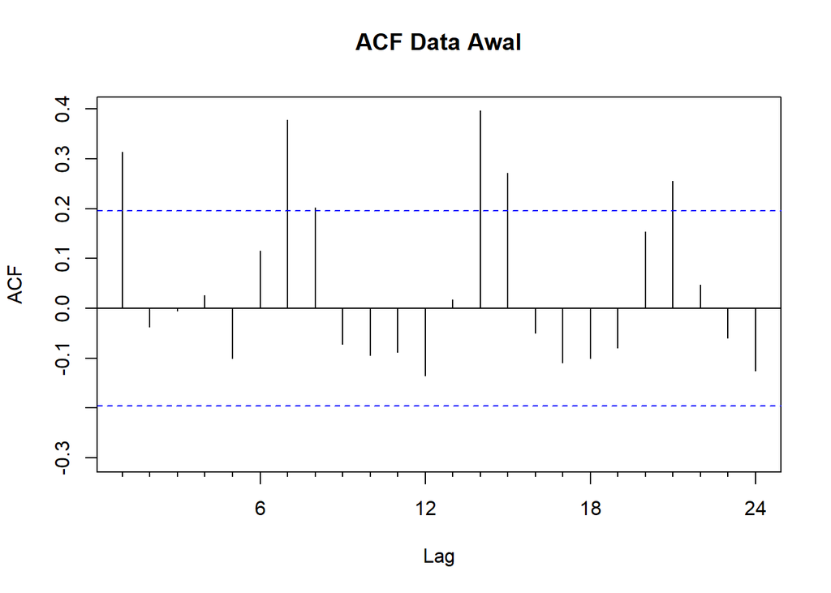

```r
Acf(y_ts,
    main = "ACF Data Awal")
```

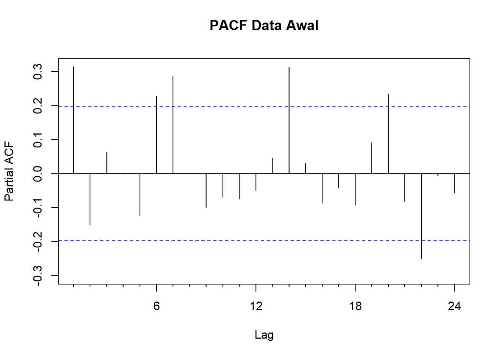

```r
Pacf(y_ts,
     main = "PACF Data Awal")
```

Pada plot ACF Data Awal, beberapa spike melewati batas signifikansi (garis biru), terutama pada lag 1, 7, 14, dan 15. Hal ini menunjukkan adanya autokorelasi yang signifikan pada beberapa lag, sehingga nilai saat ini memiliki hubungan dengan nilai pada periode sebelumnya.

Pada plot PACF Data Awal, terdapat beberapa spike yang melewati batas signifikansi, terutama pada lag 1, 6, 7, 14, 20, dan 22. Hal ini menunjukkan adanya pengaruh langsung yang signifikan dari beberapa periode sebelumnya terhadap nilai saat ini.

# Menentukan Model ARIMA

```r
model_auto <- auto.arima(y_ts)
summary(model_auto)
```

```
## Series: y_ts
## ARIMA(0,0,1) with non-zero mean
##
## Coefficients:
##          ma1       mean
##       0.3853  58664.232
## s.e.  0.0910    754.976
##
## sigma^2 = 30470412:  log likelihood = -1002.58
## AIC=2011.15   AICc=2011.4   BIC=2018.97
##
## Training set error measures:
##                   ME     RMSE      MAE        MPE    MAPE      MASE        ACF1
## Training set 32.9653 5464.522 4419.654 -0.9038156 7.91924 0.6285293 -0.01020241
```

Model yang diperoleh adalah ARIMA(0,0,1) dengan nilai MA(1) sebesar 0,3853. Nilai AIC = 2011,15 dan BIC = 2018,97 dapat digunakan untuk membandingkan model dengan kandidat lainnya. Pada data training, RMSE = 5464,52, MAE = 4419,65, dan MAPE = 7,92%, sehingga rata-rata kesalahan relatif model sekitar 7,92%.

# Cek Residual

```r
model <- Arima(y_ts, order = c(0,0,1))
summary(model)
```

```
## Series: y_ts
## ARIMA(0,0,1) with non-zero mean
##
## Coefficients:
##          ma1       mean
##       0.3853  58664.232
## s.e.  0.0910    754.976
##
## sigma^2 = 30470412:  log likelihood = -1002.58
## AIC=2011.15   AICc=2011.4   BIC=2018.97
##
## Training set error measures:
##                   ME     RMSE      MAE        MPE    MAPE      MASE        ACF1
## Training set 32.9653 5464.522 4419.654 -0.9038156 7.91924 0.6285293 -0.01020241
```

Model ARIMA(0,0,1) memiliki nilai MA(1) = 0,3853. Nilai AIC = 2011,15 dan BIC = 2018,97 menunjukkan kriteria pemilihan model. Berdasarkan data training, model menghasilkan MAPE = 7,92%, sehingga rata-rata kesalahan prediksi sekitar 7,92%.

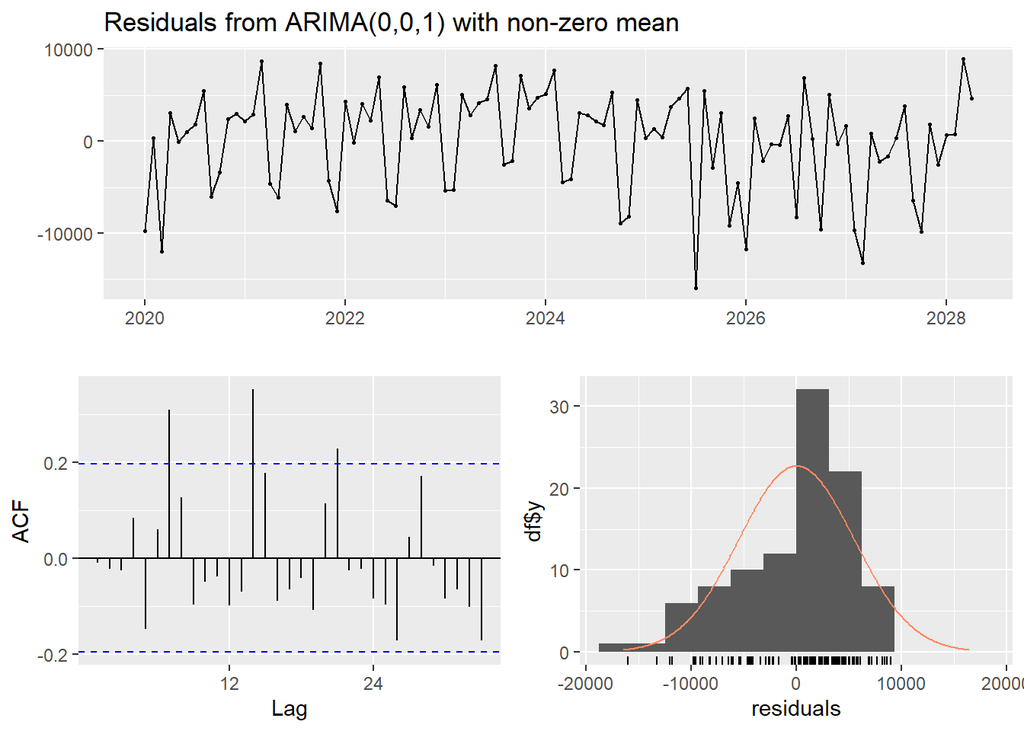

```
##
##  Ljung-Box test
##
## data:  Residuals from ARIMA(0,0,1) with non-zero mean
## Q* = 42.369, df = 19, p-value = 0.00158
##
## Model df: 1.   Total lags used: 20
```

```r
checkresiduals(model)
```

```r
Box.test(residuals(model),
         lag = 10,
         type = "Ljung-Box")
```

```
##
##  Box-Ljung test
##
## data:  residuals(model)
## X-squared = 17.267, df = 10, p-value = 0.06866
```

# FOrecasting

```r
forecast_arima <- forecast(model, h = 12)
forecast_arima
```

```
##          Point Forecast    Lo 80    Hi 80    Lo 95    Hi 95
## May 2028       60457.28 53383.11 67531.45 49638.28 71276.28
## Jun 2028       58664.23 51083.13 66245.33 47069.94 70258.52
## Jul 2028       58664.23 51083.13 66245.33 47069.94 70258.52
## Aug 2028       58664.23 51083.13 66245.33 47069.94 70258.52
## Sep 2028       58664.23 51083.13 66245.33 47069.94 70258.52
## Oct 2028       58664.23 51083.13 66245.33 47069.94 70258.52
## Nov 2028       58664.23 51083.13 66245.33 47069.94 70258.52
## Dec 2028       58664.23 51083.13 66245.33 47069.94 70258.52
## Jan 2029       58664.23 51083.13 66245.33 47069.94 70258.52
## Feb 2029       58664.23 51083.13 66245.33 47069.94 70258.52
## Mar 2029       58664.23 51083.13 66245.33 47069.94 70258.52
## Apr 2029       58664.23 51083.13 66245.33 47069.94 70258.52
```

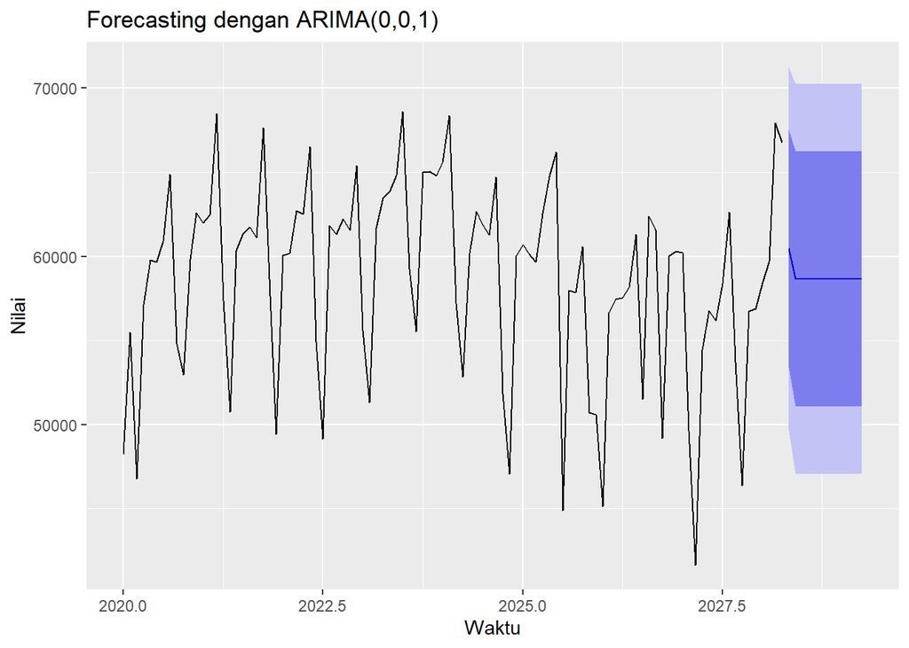

```r
autoplot(forecast_arima) +
  ggtitle("Forecasting dengan ARIMA(0,0,1)") +
  xlab("Waktu") +
  ylab("Nilai")
```